# Generating SQL for SQLite using Ollama, ChromaDB

This notebook runs through the process of using the `vanna` Python package to generate SQL using AI (RAG + LLMs) including connecting to a database and training. If you're not ready to train on your own database, you can still try it using a sample SQLite database.

### Which LLM do you want to use?

- OpenAI via Vanna.AI (Recommended)

  Use Vanna.AI for free to generate your queries
- OpenAI

  Use OpenAI with your own API key
- Azure OpenAI

  If you have OpenAI models deployed on Azure
- Ollama

  Use Ollama locally for free. Requires additional setup.
- Mistral via Mistral API

  If you have a Mistral API key
- Other LLM

  If you have a different LLM model

### Where do you want to store the 'training' data?

- Vanna Hosted Vector DB (Recommended)

  Use Vanna.AIs hosted vector database (pgvector) for free. This is usable across machines with no additional setup.
- ChromaDB

  Use ChromaDBs open-source vector database for free locally. No additional setup is necessary -- all database files will be created and stored locally.
- Marqo

  Use Marqo locally for free. Requires additional setup. Or use their hosted option.
- Other VectorDB

  Use any other vector database. Requires additional setup.

## Setup

```python
from vanna.ollama import Ollama
from vanna.chromadb.chromadb_vector import ChromaDB_VectorStore
```

```python
class MyVanna(ChromaDB_VectorStore, Ollama):
    def __init__(self, config=None):
        ChromaDB_VectorStore.__init__(self, config=config)
        Ollama.__init__(self, config=config)

config = {
    'model': 'llama3'  # 'mistral' # "starcoder2"
}
vn = MyVanna(config=config)
```

### Which database do you want to query?

- Postgres
- Microsoft SQL Server
- DuckDB
- Snowflake
- BigQuery
- SQLite
- Other Database

  Use Vanna to generate queries for any SQL database

```python
import os.path
# file_db = "./db/gpt3sql.sqlite"

file_db = "~/Downloads/chinook.sqlite"
file_db = os.path.abspath(os.path.expanduser(file_db))
vn.connect_to_sqlite(file_db)
```

```python
vn.run_sql_is_set
```

```
True
```

```python
def remove_collections(collection_name=None, ACCEPTED_TYPES = ["sql", "ddl", "documentation"]):
    if not collection_name:
        collections = ACCEPTED_TYPES
    elif isinstance(collection_name, str):
        collections = [collection_name]
    elif isinstance(collection_name, list):
        collections = collection_name
    else:
        print(f"\t{collection_name} is unknown: Skipped")
        return

    for c in collections:
        if not c in ACCEPTED_TYPES:
            print(f"\t{c} is unknown: Skipped")
            continue

        # print(f"vn.remove_collection('{c}')")
        vn.remove_collection(c)
```

```python
if False:
    remove_collections()
```

## Training

You only need to train once. Do not train again unless you want to add more training data.

```python
# show training data
training_data = vn.get_training_data()
training_data
```

|  | id | question | content | training_data_type |
| --- | --- | --- | --- | --- |
| 0 | f80850a9-c302-503b-a436-37abbfe15d4b-sql | SELECT * FROM t_person WHERE name = 'John Doe'; | SELECT * FROM t_person WHERE name = 'John Doe' | sql |
| 0 | 044ba63a-a15d-5339-b4f1-950e93c541be-ddl | None | CREATE TABLE [Invoice]\n(\n [InvoiceId] INT... | ddl |
| 1 | 291a67cf-a386-5e8a-b858-dee5a9060a31-ddl | None | CREATE TABLE [Artist]\n(\n [ArtistId] INTEG... | ddl |
| 2 | 3337d9c1-6447-541d-b8d3-9a90f3f85fc8-ddl | None | CREATE INDEX [IFK_AlbumArtistId] ON [Album] ([... | ddl |
| 3 | 344578ab-d80f-52d4-976e-78a3e54d3c6d-ddl | None | CREATE TABLE [Employee]\n(\n [EmployeeId] I... | ddl |
| 4 | 3858dfec-459a-53b5-afc9-8d854748161f-ddl | None | CREATE TABLE [MediaType]\n(\n [MediaTypeId]... | ddl |
| 5 | 52c8d5a3-d118-50af-bb23-2cd719fc02d2-ddl | None | CREATE INDEX [IFK_TrackMediaTypeId] ON [Track]... | ddl |
| 6 | 5665d55f-7b6d-5d98-8e43-6653428695fa-ddl | None | CREATE TABLE [Album]\n(\n [AlbumId] INTEGER... | ddl |
| 7 | 5793b49d-25f0-56ac-8557-45389b6ad864-ddl | None | CREATE TABLE [InvoiceLine]\n(\n [InvoiceLin... | ddl |
| 8 | 58b2d5f7-d7a5-5c6c-8708-7eb383fabb4c-ddl | None | CREATE INDEX [IFK_PlaylistTrackTrackId] ON [Pl... | ddl |
| 9 | 73b20f77-f874-5c2d-bf6f-94a43bdf5664-ddl | None | CREATE TABLE [PlaylistTrack]\n(\n [Playlist... | ddl |
| 10 | 7bd3c98d-b531-567d-b9c1-693c7cbbd5e3-ddl | None | CREATE TABLE [Genre]\n(\n [GenreId] INTEGER... | ddl |
| 11 | 898268bb-3aa1-5c1d-ab43-56a338bdef6f-ddl | None | CREATE TABLE [Customer]\n(\n [CustomerId] I... | ddl |
| 12 | 8dfd08d5-7eff-5b94-bb42-9a14d6a6501e-ddl | None | CREATE INDEX [IFK_InvoiceCustomerId] ON [Invoi... | ddl |
| 13 | 93c72821-a041-5508-a9fc-ce75311da7fd-ddl | None | CREATE INDEX [IFK_CustomerSupportRepId] ON [Cu... | ddl |
| 14 | 9444acf2-6428-5e3c-8ab1-24f92477e88e-ddl | None | CREATE TABLE [Playlist]\n(\n [PlaylistId] I... | ddl |
| 15 | 9ece6fd1-fa46-5372-b62e-cdffecc05ec3-ddl | None | CREATE INDEX [IFK_InvoiceLineInvoiceId] ON [In... | ddl |
| 16 | a4e8be30-d5dd-5a8a-aa99-64c74783e17d-ddl | None | \n CREATE TABLE IF NOT EXISTS t_person (\n ... | ddl |
| 17 | a7b444d3-8364-5e23-bafc-3baabf6cb81e-ddl | None | CREATE INDEX [IFK_TrackAlbumId] ON [Track] ([A... | ddl |
| 18 | b1fd0669-8857-586b-a285-a7b64d74ad60-ddl | None | CREATE INDEX [IFK_EmployeeReportsTo] ON [Emplo... | ddl |
| 19 | bec00095-80eb-5b53-ba91-f82738314c17-ddl | None | CREATE INDEX [IFK_TrackGenreId] ON [Track] ([G... | ddl |
| 20 | cc32717f-78e3-5bea-a82e-de699b7a1d47-ddl | None | CREATE INDEX [IFK_InvoiceLineTrackId] ON [Invo... | ddl |
| 21 | e6de8429-fd12-5c09-9c76-7725ddda2664-ddl | None | CREATE TABLE [Track]\n(\n [TrackId] INTEGER... | ddl |
| 0 | 51cf1d6d-7637-5b87-b9e7-31c577fbde59-doc | None | Our business defines OTIF score as the percent... | documentation |

## Asking the AI

Whenever you ask a new question, it will find the 10 most relevant pieces of training data and use it as part of the LLM prompt to generate the SQL.

```python
vn.ask(question="Show me a list of tables in the SQLite database")
```

```
Number of requested results 10 is greater than number of elements in index 1, updating n_results = 1
Number of requested results 10 is greater than number of elements in index 1, updating n_results = 1
```

[output not shown]

```python
vn.ask(question="How many records are in table called customer")
```

```
Number of requested results 10 is greater than number of elements in index 1, updating n_results = 1
Number of requested results 10 is greater than number of elements in index 1, updating n_results = 1
```

[output not shown]

```
Number of requested results 10 is greater than number of elements in index 1, updating n_results = 1
Number of requested results 10 is greater than number of elements in index 1, updating n_results = 1
```

````
[{'role': 'system', 'content': "You are a SQLite expert. Please help to generate a SQL query to answer the question. Your response should ONLY be based on the given context and follow the response guidelines and format instructions. \n===Tables \nCREATE TABLE [Invoice]\n(\n    [InvoiceId] INTEGER  N…
Ollama parameters:
model=llama3:latest,
options={},
keep_alive=None
Prompt Content:
[{"role": "system", "content": "You are a SQLite expert. Please help to generate a SQL query to answer the question. Your response should ONLY be based on the given context and follow the response guidelines and format instructions. \n===Tables \nCREATE TABLE [Invoice]\n(\n    [InvoiceId] INTEGER  N…
Ollama Response:
{'model': 'llama3:latest', 'created_at': '2024-06-08T19:47:02.436235536Z', 'message': {'role': 'assistant', 'content': '```\nSELECT Country, COUNT(*) AS Count\nFROM Customer\nGROUP BY Country\nORDER BY Count DESC\nLIMIT 5;\n```'}, 'done_reason': 'stop', 'done': True, 'total_duration': 71463439757, '…
```
SELECT Country, COUNT(*) AS Count
FROM Customer
GROUP BY Country
ORDER BY Count DESC
LIMIT 5;
```
Output from LLM: ```
SELECT Country, COUNT(*) AS Count
FROM Customer
GROUP BY Country
ORDER BY Count DESC
LIMIT 5;
```
Extracted SQL: SELECT Country, COUNT(*) AS Count
FROM Customer
GROUP BY Country
ORDER BY Count DESC
LIMIT 5
SELECT Country, COUNT(*) AS Count
FROM Customer
GROUP BY Country
ORDER BY Count DESC
LIMIT 5
   Country  Count
0      USA     13
1   Canada      8
2   France      5
3   Brazil      5
4  Germany      4
Ollama parameters:
model=llama3:latest,
options={},
keep_alive=None
Prompt Content:
[{"role": "system", "content": "The following is a pandas DataFrame that contains the results of the query that answers the question the user asked: 'what are the top 5 countries that customers come from?'\n\nThe DataFrame was produced using this query: SELECT Country, COUNT(*) AS Count\nFROM Custom…
Ollama Response:
{'model': 'llama3:latest', 'created_at': '2024-06-08T19:47:20.855518676Z', 'message': {'role': 'assistant', 'content': "```\nimport plotly.express as px\n\nfig = px.bar(df, x='Country', y='Count', title='Top 5 Countries by Customer Count')\n\nfig.update_traces(textposition='auto')\nfig.show()\n```"}…
````

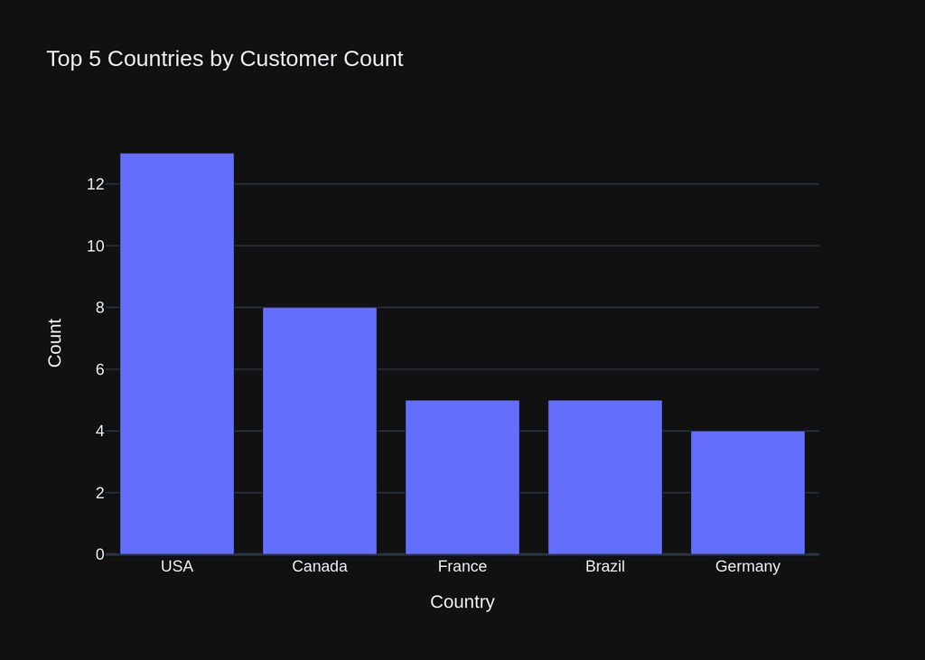

```
('SELECT Country, COUNT(*) AS Count\nFROM Customer\nGROUP BY Country\nORDER BY Count DESC\nLIMIT 5',
    Country  Count
 0      USA     13
 1   Canada      8
 2   France      5
 3   Brazil      5
 4  Germany      4,
 Figure({
     'data': [{'alignmentgroup': 'True',
               'hovertemplate': 'Country=%{x}<br>Count=%{y}<extra></extra>',
               'legendgroup': '',
               'marker': {'color': '#636efa', 'pattern': {'shape': ''}},
               'name': '',
               'offsetgroup': '',
               'orientation': 'v',
               'showlegend': False,
               'textposition': 'auto',
               'type': 'bar',
               'x': array(['USA', 'Canada', 'France', 'Brazil', 'Germany'], dtype=object),
               'xaxis': 'x',
               'y': array([13,  8,  5,  5,  4]),
               'yaxis': 'y'}],
     'layout': {'barmode': 'relative',
                'legend': {'tracegroupgap': 0},
                'template': '...',
                'title': {'text': 'Top 5 Countries by Customer Count'},
                'xaxis': {'anchor': 'y', 'domain': [0.0, 1.0], 'title': {'text': 'Country'}},
                'yaxis': {'anchor': 'x', 'domain': [0.0, 1.0], 'title': {'text': 'Count'}}}
 }))
```

```python
vn.ask(question="what are the top 5 countries that customers come from?")
```

### More SQL questions

see `sample-sql-queries-sqlite-chinook.ipynb`

```
Number of requested results 10 is greater than number of elements in index 2, updating n_results = 2
Number of requested results 10 is greater than number of elements in index 1, updating n_results = 1
```

````
[{'role': 'system', 'content': "You are a SQLite expert. Please help to generate a SQL query to answer the question. Your response should ONLY be based on the given context and follow the response guidelines and format instructions. \n===Tables \nCREATE INDEX [IFK_AlbumArtistId] ON [Album] ([ArtistI…
Ollama parameters:
model=llama3:latest,
options={},
keep_alive=None
Prompt Content:
[{"role": "system", "content": "You are a SQLite expert. Please help to generate a SQL query to answer the question. Your response should ONLY be based on the given context and follow the response guidelines and format instructions. \n===Tables \nCREATE INDEX [IFK_AlbumArtistId] ON [Album] ([ArtistI…
Ollama Response:
{'model': 'llama3:latest', 'created_at': '2024-06-08T19:48:25.135322138Z', 'message': {'role': 'assistant', 'content': 'SELECT A.Title, A.ArtistId, ART.Name \nFROM Album A \nJOIN Artist ART ON A.ArtistId = ART.ArtistId;'}, 'done_reason': 'stop', 'done': True, 'total_duration': 63620730653, 'load_dur…
SELECT A.Title, A.ArtistId, ART.Name
FROM Album A
JOIN Artist ART ON A.ArtistId = ART.ArtistId;
Output from LLM: SELECT A.Title, A.ArtistId, ART.Name
FROM Album A
JOIN Artist ART ON A.ArtistId = ART.ArtistId;
Extracted SQL: SELECT A.Title, A.ArtistId, ART.Name
FROM Album A
JOIN Artist ART ON A.ArtistId = ART.ArtistId
SELECT A.Title, A.ArtistId, ART.Name
FROM Album A
JOIN Artist ART ON A.ArtistId = ART.ArtistId
                                                 Title  ArtistId  \
0                For Those About To Rock We Salute You         1
1                                    Balls to the Wall         2
2                                    Restless and Wild         2
3                                    Let There Be Rock         1
4                                             Big Ones         3
..                                                 ...       ...
342                             Respighi:Pines of Rome       226
343  Schubert: The Late String Quartets & String Qu...       272
344                                Monteverdi: L'Orfeo       273
345                              Mozart: Chamber Music       274
346  Koyaanisqatsi (Soundtrack from the Motion Pict...       275

                                                  Name
0                                                AC/DC
1                                               Accept
2                                               Accept
3                                                AC/DC
4                                            Aerosmith
..                                                 ...
342                                     Eugene Ormandy
343                             Emerson String Quartet
344  C. Monteverdi, Nigel Rogers - Chiaroscuro; Lon...
345                                      Nash Ensemble
346                              Philip Glass Ensemble

[347 rows x 3 columns]
Ollama parameters:
model=llama3:latest,
options={},
keep_alive=None
Prompt Content:
[{"role": "system", "content": "The following is a pandas DataFrame that contains the results of the query that answers the question the user asked: '  \n    List all albums and their corresponding artist names  \n'\n\nThe DataFrame was produced using this query: SELECT A.Title, A.ArtistId, ART.Name…
Ollama Response:
{'model': 'llama3:latest', 'created_at': '2024-06-08T19:48:44.857642836Z', 'message': {'role': 'assistant', 'content': '```\nimport plotly.express as px\nimport numpy as np\n\nfig = px.bar(df, x=\'ArtistId\', y=\'Title\', color=\'Name\')\nfig.update_layout(title_text="Albums by Artist")\nfig.show()\…
````

[figure not shown]

[output not shown]

[output cut: 2905 more lines]

[output not shown]

```python
question = """
    List all albums and their corresponding artist names
"""

vn.ask(question=question)
```

```
Number of requested results 10 is greater than number of elements in index 3, updating n_results = 3
Number of requested results 10 is greater than number of elements in index 1, updating n_results = 1
```

```
[{'role': 'system', 'content': "You are a SQLite expert. Please help to generate a SQL query to answer the question. Your response should ONLY be based on the given context and follow the response guidelines and format instructions. \n===Tables \nCREATE INDEX [IFK_TrackGenreId] ON [Track] ([GenreId]…
Ollama parameters:
model=llama3:latest,
options={},
keep_alive=None
Prompt Content:
[{"role": "system", "content": "You are a SQLite expert. Please help to generate a SQL query to answer the question. Your response should ONLY be based on the given context and follow the response guidelines and format instructions. \n===Tables \nCREATE INDEX [IFK_TrackGenreId] ON [Track] ([GenreId]…
Ollama Response:
{'model': 'llama3:latest', 'created_at': '2024-06-08T19:49:50.396655881Z', 'message': {'role': 'assistant', 'content': "SELECT *\nFROM Track\nWHERE LOWER(Name) LIKE '%what%';"}, 'done_reason': 'stop', 'done': True, 'total_duration': 64390640532, 'load_duration': 542078, 'prompt_eval_count': 998, 'pr…
SELECT *
FROM Track
WHERE LOWER(Name) LIKE '%what%';
Output from LLM: SELECT *
FROM Track
WHERE LOWER(Name) LIKE '%what%';
Extracted SQL: SELECT *
FROM Track
WHERE LOWER(Name) LIKE '%what%'
SELECT *
FROM Track
WHERE LOWER(Name) LIKE '%what%'
    TrackId                                          Name  AlbumId  \
0        26                                 What It Takes        5
1        88                                  What You Are       10
2       130                             Do what cha wanna       13
3       342                   What is and Should Never Be       30
4       607                                       So What       48
5       960                                    What A Day       76
6      1000                                 What If I Do?       80
7      1039                              What Now My Love       83
8      1145                                   Whatsername       89
9      1440             Whatever It Is, I Just Can't Stop      116
10     1469                         Look What You've Done      119
11     1470                             Get What You Need      119
12     1628              What Is And What Should Never Be      133
13     1778  You're What's Happening (In The World Today)      146
14     1823                                       So What      149
15     2772           I Don't Know What To Do With Myself      223
16     2884                                 What Kate Did      231
17     2893                      Whatever the Case May Be      230
```

[output cut: 45 more lines]

````
15        221387    7251478       0.99
16       2610250  484583988       1.99
17       2616410  183867185       1.99
18        353567   11542247       0.99
19        280764    9306737       0.99
20        215084    3499018       0.99
21        209573    3426106       0.99
Ollama parameters:
model=llama3:latest,
options={},
keep_alive=None
Prompt Content:
[{"role": "system", "content": "The following is a pandas DataFrame that contains the results of the query that answers the question the user asked: '  \n    Find all tracks with a name containing \"What\" (case-insensitive)\n'\n\nThe DataFrame was produced using this query: SELECT *\nFROM Track\nWH…
Ollama Response:
{'model': 'llama3:latest', 'created_at': '2024-06-08T19:50:10.86894395Z', 'message': {'role': 'assistant', 'content': "```\nimport plotly.express as px\nimport plotly.graph_objects as go\n\nfig = go.Figure(data=[go.Bar(x=df['Name'], y=df['UnitPrice'])])\n\nfig.show()\n```"}, 'done_reason': 'stop', '…
````

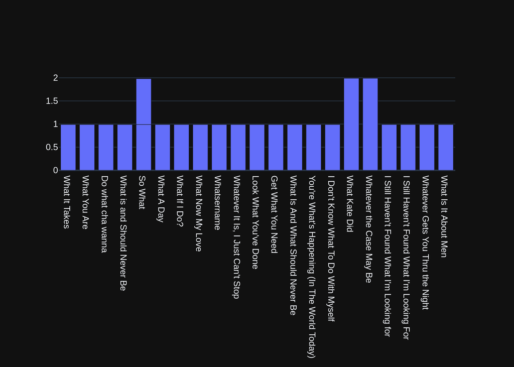

```
("SELECT *\nFROM Track\nWHERE LOWER(Name) LIKE '%what%'",
     TrackId                                          Name  AlbumId  \
 0        26                                 What It Takes        5
 1        88                                  What You Are       10
 2       130                             Do what cha wanna       13
 3       342                   What is and Should Never Be       30
 4       607                                       So What       48
 5       960                                    What A Day       76
 6      1000                                 What If I Do?       80
 7      1039                              What Now My Love       83
 8      1145                                   Whatsername       89
 9      1440             Whatever It Is, I Just Can't Stop      116
 10     1469                         Look What You've Done      119
 11     1470                             Get What You Need      119
 12     1628              What Is And What Should Never Be      133
```

[output cut: 75 more lines]

```python
question = """
    Find all tracks with a name containing "What" (case-insensitive)
"""

vn.ask(question=question)
```

```python
question = """
    Get the total number of invoices for each customer
"""

vn.ask(question=question)
```

```
Number of requested results 10 is greater than number of elements in index 4, updating n_results = 4
Number of requested results 10 is greater than number of elements in index 1, updating n_results = 1
```

[output not shown]

```python
question = """
    Find the total number of invoices per country:
"""

vn.ask(question=question)
```

```
Number of requested results 10 is greater than number of elements in index 4, updating n_results = 4
Number of requested results 10 is greater than number of elements in index 1, updating n_results = 1
```

[output not shown]

```
Number of requested results 10 is greater than number of elements in index 4, updating n_results = 4
Number of requested results 10 is greater than number of elements in index 1, updating n_results = 1
```

````
[{'role': 'system', 'content': "You are a SQLite expert. Please help to generate a SQL query to answer the question. Your response should ONLY be based on the given context and follow the response guidelines and format instructions. \n===Tables \nCREATE TABLE [Invoice]\n(\n    [InvoiceId] INTEGER  N…
Ollama parameters:
model=llama3:latest,
options={},
keep_alive=None
Prompt Content:
[{"role": "system", "content": "You are a SQLite expert. Please help to generate a SQL query to answer the question. Your response should ONLY be based on the given context and follow the response guidelines and format instructions. \n===Tables \nCREATE TABLE [Invoice]\n(\n    [InvoiceId] INTEGER  N…
Ollama Response:
{'model': 'llama3:latest', 'created_at': '2024-06-08T19:54:33.8166476Z', 'message': {'role': 'assistant', 'content': 'SELECT * \nFROM Invoice'}, 'done_reason': 'stop', 'done': True, 'total_duration': 81704951265, 'load_duration': 635728, 'prompt_eval_count': 1274, 'prompt_eval_duration': 80492136000…
SELECT *
FROM Invoice
SELECT *
FROM Invoice
     InvoiceId  CustomerId          InvoiceDate  \
0            1           2  2009-01-01 00:00:00
1            2           4  2009-01-02 00:00:00
2            3           8  2009-01-03 00:00:00
3            4          14  2009-01-06 00:00:00
4            5          23  2009-01-11 00:00:00
..         ...         ...                  ...
407        408          25  2013-12-05 00:00:00
408        409          29  2013-12-06 00:00:00
409        410          35  2013-12-09 00:00:00
410        411          44  2013-12-14 00:00:00
411        412          58  2013-12-22 00:00:00

                               BillingAddress BillingCity BillingState  \
0                     Theodor-Heuss-Straße 34   Stuttgart         None
1                            Ullevålsveien 14        Oslo         None
2                             Grétrystraat 63    Brussels         None
3                              8210 111 ST NW    Edmonton           AB
4                             69 Salem Street      Boston           MA
..                                        ...         ...          ...
407                     319 N. Frances Street     Madison           WI
408                    796 Dundas Street West     Toronto           ON
409  Rua dos Campeões Europeus de Viena, 4350       Porto         None
410                           Porthaninkatu 9    Helsinki         None
411                       12,Community Centre       Delhi         None

    BillingCountry BillingPostalCode  Total
0          Germany             70174   1.98
1           Norway              0171   3.96
2          Belgium              1000   5.94
3           Canada           T6G 2C7   8.91
4              USA              2113  13.86
..             ...               ...    ...
407            USA             53703   3.96
408         Canada           M6J 1V1   5.94
409       Portugal              None   8.91
410        Finland             00530  13.86
411          India            110017   1.99

[412 rows x 9 columns]
Ollama parameters:
model=llama3:latest,
options={},
keep_alive=None
Prompt Content:
[{"role": "system", "content": "The following is a pandas DataFrame that contains the results of the query that answers the question the user asked: '  \n    List all invoices with a total exceeding $10:\n'\n\nThe DataFrame was produced using this query: SELECT * \nFROM Invoice\n\nThe following is i…
Ollama Response:
{'model': 'llama3:latest', 'created_at': '2024-06-08T19:54:56.865546876Z', 'message': {'role': 'assistant', 'content': "```\nimport plotly.express as px\nimport plotly.graph_objects as go\n\nfig = px.bar(df, x='InvoiceId', y='Total')\n\nfig.update_layout(title='Invoices with Total Exceeding $10',\n …
````

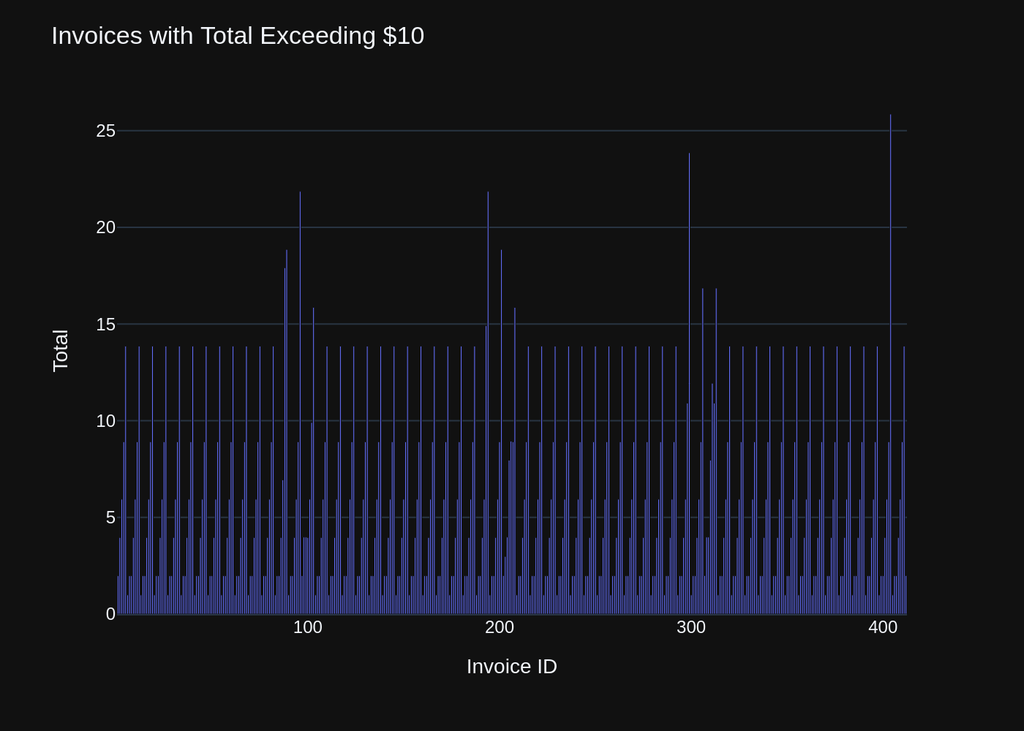

```
('SELECT * \nFROM Invoice',
      InvoiceId  CustomerId          InvoiceDate  \
 0            1           2  2009-01-01 00:00:00
 1            2           4  2009-01-02 00:00:00
 2            3           8  2009-01-03 00:00:00
 3            4          14  2009-01-06 00:00:00
 4            5          23  2009-01-11 00:00:00
 ..         ...         ...                  ...
 407        408          25  2013-12-05 00:00:00
 408        409          29  2013-12-06 00:00:00
 409        410          35  2013-12-09 00:00:00
 410        411          44  2013-12-14 00:00:00
 411        412          58  2013-12-22 00:00:00

                                BillingAddress BillingCity BillingState  \
 0                     Theodor-Heuss-Straße 34   Stuttgart         None
 1                            Ullevålsveien 14        Oslo         None
 2                             Grétrystraat 63    Brussels         None
 3                              8210 111 ST NW    Edmonton           AB
 4                             69 Salem Street      Boston           MA
 ..                                        ...         ...          ...
 407                     319 N. Frances Street     Madison           WI
 408                    796 Dundas Street West     Toronto           ON
 409  Rua dos Campeões Europeus de Viena, 4350       Porto         None
 410                           Porthaninkatu 9    Helsinki         None
 411                       12,Community Centre       Delhi         None

     BillingCountry BillingPostalCode  Total
 0          Germany             70174   1.98
 1           Norway              0171   3.96
 2          Belgium              1000   5.94
 3           Canada           T6G 2C7   8.91
 4              USA              2113  13.86
 ..             ...               ...    ...
 407            USA             53703   3.96
 408         Canada           M6J 1V1   5.94
 409       Portugal              None   8.91
 410        Finland             00530  13.86
 411          India            110017   1.99

```

[output cut: 9 more lines]

```
               'showlegend': False,
               'textposition': 'auto',
               'type': 'bar',
               'x': array([  1,   2,   3, ..., 410, 411, 412]),
               'xaxis': 'x',
               'y': array([ 1.98,  3.96,  5.94, ...,  8.91, 13.86,  1.99]),
               'yaxis': 'y'}],
     'layout': {'barmode': 'relative',
                'legend': {'tracegroupgap': 0},
                'margin': {'t': 60},
                'template': '...',
                'title': {'text': 'Invoices with Total Exceeding $10'},
                'xaxis': {'anchor': 'y', 'domain': [0.0, 1.0], 'title': {'text': 'Invoice ID'}},
                'yaxis': {'anchor': 'x', 'domain': [0.0, 1.0], 'title': {'text': 'Total'}}}
 }))
```

```python
question = """
    List all invoices with a total exceeding $10:
"""

vn.ask(question=question)
```

```python
question = """
    Find all invoices since 2010 and the total amount invoiced:
"""

vn.ask(question=question)
```

```
Number of requested results 10 is greater than number of elements in index 5, updating n_results = 5
Number of requested results 10 is greater than number of elements in index 1, updating n_results = 1
```

[output not shown]

```
Number of requested results 10 is greater than number of elements in index 5, updating n_results = 5
Number of requested results 10 is greater than number of elements in index 1, updating n_results = 1
```

````
[{'role': 'system', 'content': "You are a SQLite expert. Please help to generate a SQL query to answer the question. Your response should ONLY be based on the given context and follow the response guidelines and format instructions. \n===Tables \nCREATE INDEX [IFK_EmployeeReportsTo] ON [Employee] ([…
Ollama parameters:
model=llama3:latest,
options={},
keep_alive=None
Prompt Content:
[{"role": "system", "content": "You are a SQLite expert. Please help to generate a SQL query to answer the question. Your response should ONLY be based on the given context and follow the response guidelines and format instructions. \n===Tables \nCREATE INDEX [IFK_EmployeeReportsTo] ON [Employee] ([…
Ollama Response:
{'model': 'llama3:latest', 'created_at': '2024-06-08T19:58:11.541035285Z', 'message': {'role': 'assistant', 'content': "SELECT E.LastName, E.FirstName, \n       CASE WHEN ReportsTo IS NULL THEN 'N/A' ELSE (SELECT LastName + ', ' + FirstName FROM Employee WHERE EmployeeId = E.ReportsTo) END AS Report…
SELECT E.LastName, E.FirstName,
       CASE WHEN ReportsTo IS NULL THEN 'N/A' ELSE (SELECT LastName + ', ' + FirstName FROM Employee WHERE EmployeeId = E.ReportsTo) END AS ReportingManager
FROM Employee E
SELECT E.LastName, E.FirstName,
       CASE WHEN ReportsTo IS NULL THEN 'N/A' ELSE (SELECT LastName + ', ' + FirstName FROM Employee WHERE EmployeeId = E.ReportsTo) END AS ReportingManager
FROM Employee E
   LastName FirstName ReportingManager
0     Adams    Andrew              N/A
1   Edwards     Nancy                0
2   Peacock      Jane                0
3      Park  Margaret                0
4   Johnson     Steve                0
5  Mitchell   Michael                0
6      King    Robert                0
7  Callahan     Laura                0
Ollama parameters:
model=llama3:latest,
options={},
keep_alive=None
Prompt Content:
[{"role": "system", "content": "The following is a pandas DataFrame that contains the results of the query that answers the question the user asked: '  \n    List all employees and their reporting manager's name (if any):\n'\n\nThe DataFrame was produced using this query: SELECT E.LastName, E.FirstN…
Ollama Response:
{'model': 'llama3:latest', 'created_at': '2024-06-08T19:58:39.464719374Z', 'message': {'role': 'assistant', 'content': '```\nimport plotly.express as px\n\nfig = px.bar(df, x=\'LastName\', y=\'ReportingManager\', title=\'Employee Reporting Manager\')\nfig.update_layout(yaxis_title=\'Reporting Manage…
````

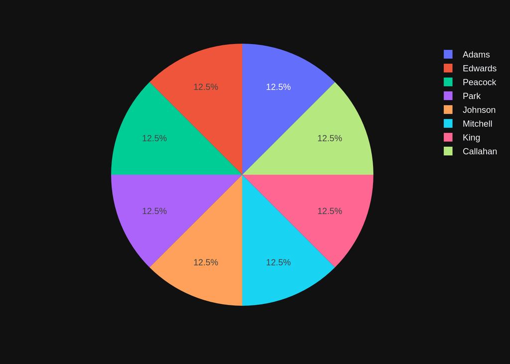

```
("SELECT E.LastName, E.FirstName, \n       CASE WHEN ReportsTo IS NULL THEN 'N/A' ELSE (SELECT LastName + ', ' + FirstName FROM Employee WHERE EmployeeId = E.ReportsTo) END AS ReportingManager\nFROM Employee E",
    LastName FirstName ReportingManager
 0     Adams    Andrew              N/A
 1   Edwards     Nancy                0
 2   Peacock      Jane                0
 3      Park  Margaret                0
 4   Johnson     Steve                0
 5  Mitchell   Michael                0
 6      King    Robert                0
 7  Callahan     Laura                0,
 Figure({
     'data': [{'domain': {'x': [0.0, 1.0], 'y': [0.0, 1.0]},
               'hovertemplate': 'LastName=%{label}<extra></extra>',
               'labels': array(['Adams', 'Edwards', 'Peacock', 'Park', 'Johnson', 'Mitchell', 'King',
                                'Callahan'], dtype=object),
               'legendgroup': '',
               'name': '',
               'showlegend': True,
               'type': 'pie'}],
     'layout': {'legend': {'tracegroupgap': 0}, 'margin': {'t': 60}, 'template': '...'}
 }))
```

```python
question = """
    List all employees and their reporting manager's name (if any):
"""

vn.ask(question=question)
```

```
Number of requested results 10 is greater than number of elements in index 6, updating n_results = 6
Number of requested results 10 is greater than number of elements in index 1, updating n_results = 1
```

```
[{'role': 'system', 'content': "You are a SQLite expert. Please help to generate a SQL query to answer the question. Your response should ONLY be based on the given context and follow the response guidelines and format instructions. \n===Tables \nCREATE INDEX [IFK_InvoiceCustomerId] ON [Invoice] ([C…
Ollama parameters:
model=llama3:latest,
options={},
keep_alive=None
Prompt Content:
[{"role": "system", "content": "You are a SQLite expert. Please help to generate a SQL query to answer the question. Your response should ONLY be based on the given context and follow the response guidelines and format instructions. \n===Tables \nCREATE INDEX [IFK_InvoiceCustomerId] ON [Invoice] ([C…
Ollama Response:
{'model': 'llama3:latest', 'created_at': '2024-06-08T20:00:15.098873637Z', 'message': {'role': 'assistant', 'content': 'SELECT C.LastName, AVG(I.Total) AS AverageInvoiceTotal\nFROM Customer C\nJOIN Invoice I ON C.CustomerId = I.CustomerId\nGROUP BY C.LastName'}, 'done_reason': 'stop', 'done': True, …
SELECT C.LastName, AVG(I.Total) AS AverageInvoiceTotal
FROM Customer C
JOIN Invoice I ON C.CustomerId = I.CustomerId
GROUP BY C.LastName
SELECT C.LastName, AVG(I.Total) AS AverageInvoiceTotal
FROM Customer C
JOIN Invoice I ON C.CustomerId = I.CustomerId
GROUP BY C.LastName
        LastName  AverageInvoiceTotal
0        Almeida             5.374286
1        Barnett             6.231429
2        Bernard             5.517143
3         Brooks             5.374286
4          Brown             5.374286
5          Chase             5.374286
6     Cunningham             6.802857
7         Dubois             5.374286
8      Fernandes             5.660000
9        Francis             5.374286
10        Girard             5.660000
11     Gonçalves             5.660000
12        Gordon             5.374286
13         Goyer             5.517143
14          Gray             5.374286
15        Gruber             6.088571
16     Gutiérrez             5.374286
17        Hansen             5.660000
18        Harris             5.374286
19          Holý             7.088571
20        Hughes             5.374286
21    Hämäläinen             5.945714
```

[output cut: 30 more lines]

````
52      Sullivan             5.374286
53        Taylor             5.374286
54      Tremblay             5.660000
55  Van der Berg             5.802857
56   Wichterlová             5.802857
57        Wójcik             5.374286
58    Zimmermann             6.231429
Ollama parameters:
model=llama3:latest,
options={},
keep_alive=None
Prompt Content:
[{"role": "system", "content": "The following is a pandas DataFrame that contains the results of the query that answers the question the user asked: '  \n    Get the average invoice total for each customer:\n'\n\nThe DataFrame was produced using this query: SELECT C.LastName, AVG(I.Total) AS Average…
Ollama Response:
{'model': 'llama3:latest', 'created_at': '2024-06-08T20:00:36.382523615Z', 'message': {'role': 'assistant', 'content': "```\nimport plotly.express as px\n\nfig = px.bar(df, x='LastName', y='AverageInvoiceTotal')\n\nfig.update_layout(title='Average Invoice Total by Customer',\n                  yaxis…
````

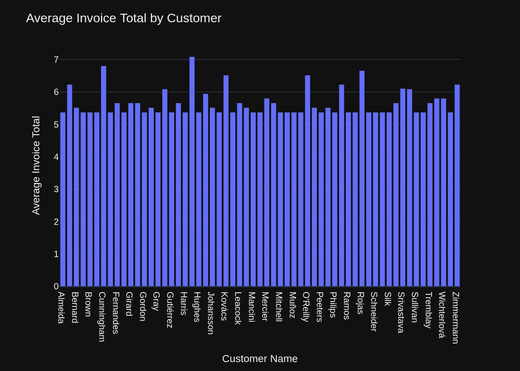

```
('SELECT C.LastName, AVG(I.Total) AS AverageInvoiceTotal\nFROM Customer C\nJOIN Invoice I ON C.CustomerId = I.CustomerId\nGROUP BY C.LastName',
         LastName  AverageInvoiceTotal
 0        Almeida             5.374286
 1        Barnett             6.231429
 2        Bernard             5.517143
 3         Brooks             5.374286
 4          Brown             5.374286
 5          Chase             5.374286
 6     Cunningham             6.802857
 7         Dubois             5.374286
 8      Fernandes             5.660000
 9        Francis             5.374286
 10        Girard             5.660000
 11     Gonçalves             5.660000
 12        Gordon             5.374286
 13         Goyer             5.517143
 14          Gray             5.374286
 15        Gruber             6.088571
 16     Gutiérrez             5.374286
 17        Hansen             5.660000
 18        Harris             5.374286
 19          Holý             7.088571
 20        Hughes             5.374286
 21    Hämäläinen             5.945714
 22     Johansson             5.517143
 23         Jones             5.374286
 24        Kovács             6.517143
 25        Köhler             5.374286
 26       Leacock             5.660000
 27      Lefebvre             5.517143
 28       Mancini             5.374286
 29       Martins             5.374286
 30       Mercier             5.802857
 31        Miller             5.660000
 32      Mitchell             5.374286
 33        Murray             5.374286
 34         Muñoz             5.374286
 35       Nielsen             5.374286
 36      O'Reilly             6.517143
 37        Pareek             5.517143
```

[output cut: 47 more lines]

```
                           6.51714286, 5.37428571, 5.66      , 5.51714286, 5.37428571, 5.37428571,
                           5.80285714, 5.66      , 5.37428571, 5.37428571, 5.37428571, 5.37428571,
                           6.51714286, 5.51714286, 5.37428571, 5.51714286, 5.37428571, 6.23142857,
                           5.37428571, 5.37428571, 6.66      , 5.37428571, 5.37428571, 5.37428571,
                           5.37428571, 5.66      , 6.10666667, 6.08857143, 5.37428571, 5.37428571,
                           5.66      , 5.80285714, 5.80285714, 5.37428571, 6.23142857]),
               'yaxis': 'y'}],
     'layout': {'barmode': 'relative',
                'legend': {'tracegroupgap': 0},
                'margin': {'t': 60},
                'template': '...',
                'title': {'text': 'Average Invoice Total by Customer'},
                'xaxis': {'anchor': 'y', 'domain': [0.0, 1.0], 'title': {'text': 'Customer Name'}},
                'yaxis': {'anchor': 'x', 'domain': [0.0, 1.0], 'title': {'text': 'Average Invoice Total'}}}
 }))
```

```python
question = """
    Get the average invoice total for each customer:
"""

vn.ask(question=question)
```

```python
question = """
    Find the top 5 most expensive tracks (based on unit price):
"""

vn.ask(question=question)
```

```
Number of requested results 10 is greater than number of elements in index 7, updating n_results = 7
Number of requested results 10 is greater than number of elements in index 1, updating n_results = 1
```

[output not shown]

```
Number of requested results 10 is greater than number of elements in index 7, updating n_results = 7
Number of requested results 10 is greater than number of elements in index 1, updating n_results = 1
```

````
[{'role': 'system', 'content': "You are a SQLite expert. Please help to generate a SQL query to answer the question. Your response should ONLY be based on the given context and follow the response guidelines and format instructions. \n===Tables \nCREATE INDEX [IFK_TrackGenreId] ON [Track] ([GenreId]…
Ollama parameters:
model=llama3:latest,
options={},
keep_alive=None
Prompt Content:
[{"role": "system", "content": "You are a SQLite expert. Please help to generate a SQL query to answer the question. Your response should ONLY be based on the given context and follow the response guidelines and format instructions. \n===Tables \nCREATE INDEX [IFK_TrackGenreId] ON [Track] ([GenreId]…
Ollama Response:
{'model': 'llama3:latest', 'created_at': '2024-06-08T20:03:23.855543745Z', 'message': {'role': 'assistant', 'content': 'SELECT G.Name, COUNT(T.TrackId) AS TrackCount \nFROM Genre G \nLEFT JOIN Track T ON G.GenreId = T.GenreId \nGROUP BY G.Name'}, 'done_reason': 'stop', 'done': True, 'total_duration'…
SELECT G.Name, COUNT(T.TrackId) AS TrackCount
FROM Genre G
LEFT JOIN Track T ON G.GenreId = T.GenreId
GROUP BY G.Name
SELECT G.Name, COUNT(T.TrackId) AS TrackCount
FROM Genre G
LEFT JOIN Track T ON G.GenreId = T.GenreId
GROUP BY G.Name
                  Name  TrackCount
0          Alternative          40
1   Alternative & Punk         332
2                Blues          81
3           Bossa Nova          15
4            Classical          74
5               Comedy          17
6                Drama          64
7       Easy Listening          24
8    Electronica/Dance          30
9          Heavy Metal          28
10         Hip Hop/Rap          35
11                Jazz         130
12               Latin         579
13               Metal         374
14               Opera           1
15                 Pop          48
16            R&B/Soul          61
17              Reggae          58
18                Rock        1297
19       Rock And Roll          12
20    Sci Fi & Fantasy          26
21     Science Fiction          13
22          Soundtrack          43
23            TV Shows          93
24               World          28
Ollama parameters:
model=llama3:latest,
options={},
keep_alive=None
Prompt Content:
[{"role": "system", "content": "The following is a pandas DataFrame that contains the results of the query that answers the question the user asked: '  \n    List all genres and the number of tracks in each genre:\n'\n\nThe DataFrame was produced using this query: SELECT G.Name, COUNT(T.TrackId) AS …
Ollama Response:
{'model': 'llama3:latest', 'created_at': '2024-06-08T20:03:43.058916498Z', 'message': {'role': 'assistant', 'content': "```\nimport plotly.express as px\nimport plotly.graph_objects as go\n\nfig = px.bar(df, x='Name', y='TrackCount', title='Genre Track Count')\nfig.show()\n```"}, 'done_reason': 'sto…
````

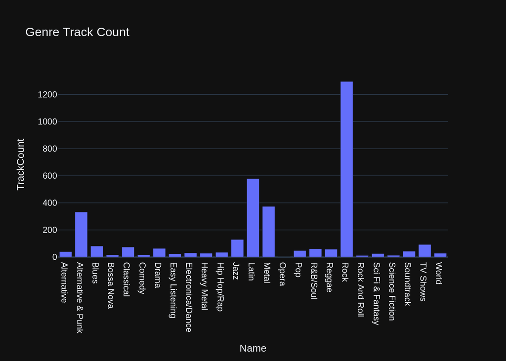

```
('SELECT G.Name, COUNT(T.TrackId) AS TrackCount \nFROM Genre G \nLEFT JOIN Track T ON G.GenreId = T.GenreId \nGROUP BY G.Name',
                   Name  TrackCount
 0          Alternative          40
 1   Alternative & Punk         332
 2                Blues          81
 3           Bossa Nova          15
 4            Classical          74
 5               Comedy          17
 6                Drama          64
 7       Easy Listening          24
 8    Electronica/Dance          30
 9          Heavy Metal          28
 10         Hip Hop/Rap          35
 11                Jazz         130
 12               Latin         579
 13               Metal         374
 14               Opera           1
 15                 Pop          48
 16            R&B/Soul          61
 17              Reggae          58
 18                Rock        1297
 19       Rock And Roll          12
 20    Sci Fi & Fantasy          26
 21     Science Fiction          13
 22          Soundtrack          43
 23            TV Shows          93
 24               World          28,
 Figure({
     'data': [{'alignmentgroup': 'True',
               'hovertemplate': 'Name=%{x}<br>TrackCount=%{y}<extra></extra>',
               'legendgroup': '',
               'marker': {'color': '#636efa', 'pattern': {'shape': ''}},
               'name': '',
               'offsetgroup': '',
               'orientation': 'v',
               'showlegend': False,
               'textposition': 'auto',
               'type': 'bar',
               'x': array(['Alternative', 'Alternative & Punk', 'Blues', 'Bossa Nova', 'Classical',
                           'Comedy', 'Drama', 'Easy Listening', 'Electronica/Dance', 'Heavy Metal',
                           'Hip Hop/Rap', 'Jazz', 'Latin', 'Metal', 'Opera', 'Pop', 'R&B/Soul',
                           'Reggae', 'Rock', 'Rock And Roll', 'Sci Fi & Fantasy',
                           'Science Fiction', 'Soundtrack', 'TV Shows', 'World'], dtype=object),
               'xaxis': 'x',
               'y': array([  40,  332,   81,   15,   74,   17,   64,   24,   30,   28,   35,  130,
                            579,  374,    1,   48,   61,   58, 1297,   12,   26,   13,   43,   93,
                             28]),
               'yaxis': 'y'}],
     'layout': {'barmode': 'relative',
                'legend': {'tracegroupgap': 0},
                'template': '...',
                'title': {'text': 'Genre Track Count'},
                'xaxis': {'anchor': 'y', 'domain': [0.0, 1.0], 'title': {'text': 'Name'}},
                'yaxis': {'anchor': 'x', 'domain': [0.0, 1.0], 'title': {'text': 'TrackCount'}}}
 }))
```

```python
question = """
    List all genres and the number of tracks in each genre:
"""

vn.ask(question=question)
```

```python
question = """
    Get all genres that do not have any tracks associated with them:
"""

vn.ask(question=question)
```

```
Number of requested results 10 is greater than number of elements in index 8, updating n_results = 8
Number of requested results 10 is greater than number of elements in index 1, updating n_results = 1
```

[output not shown]

```
('SELECT G.Name\nFROM Genre G\nLEFT JOIN Track T ON G.GenreId = T.GenreId\nWHERE T.TrackId IS NULL',
 Empty DataFrame
 Columns: [Name]
 Index: [],
 Figure({
     'data': [{'domain': {'x': [0.0, 1.0], 'y': [0.0, 1.0]},
               'hovertemplate': 'Name=%{label}<extra></extra>',
               'labels': array([], dtype=object),
               'legendgroup': '',
               'name': '',
               'showlegend': True,
               'type': 'pie'}],
     'layout': {'legend': {'tracegroupgap': 0}, 'margin': {'t': 60}, 'template': '...'}
 }))
```

```python
question = """
    List all customers who have not placed any orders:
"""

vn.ask(question=question)
```

```
Number of requested results 10 is greater than number of elements in index 8, updating n_results = 8
Number of requested results 10 is greater than number of elements in index 1, updating n_results = 1
```

[output not shown]

```
('SELECT C.*\nFROM Customer C\nLEFT JOIN (\n    SELECT CustomerId\n    FROM Invoice\n) I ON C.CustomerId = I.CustomerId\nWHERE I.CustomerId IS NULL',
 Empty DataFrame
 Columns: [CustomerId, FirstName, LastName, Company, Address, City, State, Country, PostalCode, Phone, Fax, Email, SupportRepId]
 Index: [],
 Figure({
     'data': [{'domain': {'x': [0.0, 1.0], 'y': [0.0, 1.0]},
               'hovertemplate': 'CustomerId=%{label}<extra></extra>',
               'labels': array([], dtype=object),
               'legendgroup': '',
               'name': '',
               'showlegend': True,
               'type': 'pie'}],
     'layout': {'legend': {'tracegroupgap': 0}, 'margin': {'t': 60}, 'template': '...'}
 }))
```

```python
question = """
    Get the top 10 most popular artists (based on the number of tracks):
"""

vn.ask(question=question)
```

```
Number of requested results 10 is greater than number of elements in index 8, updating n_results = 8
Number of requested results 10 is greater than number of elements in index 1, updating n_results = 1
```

[output not shown]

```
Number of requested results 10 is greater than number of elements in index 8, updating n_results = 8
Number of requested results 10 is greater than number of elements in index 1, updating n_results = 1
```

[output not shown]

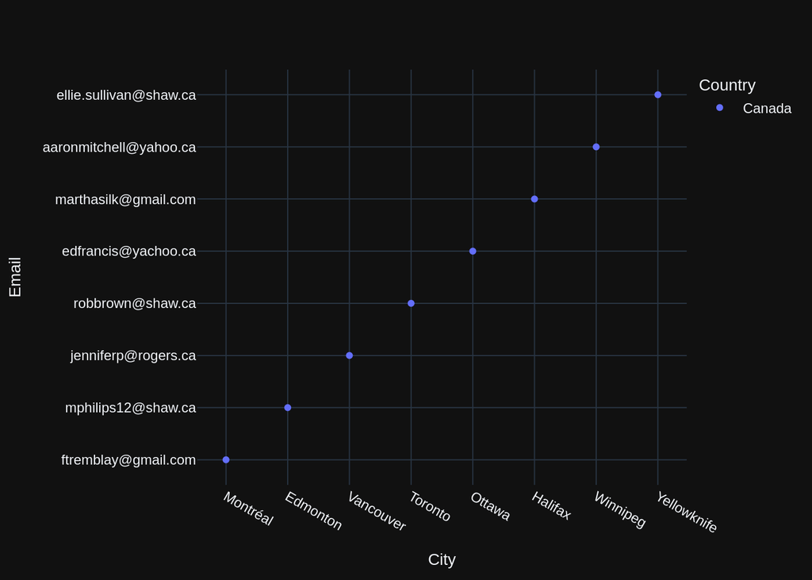

```
("SELECT Email, City, Country\nFROM Customer\nWHERE Country = 'Canada'\n",
                     Email         City Country
 0     ftremblay@gmail.com     Montréal  Canada
 1      mphilips12@shaw.ca     Edmonton  Canada
 2     jenniferp@rogers.ca    Vancouver  Canada
 3        robbrown@shaw.ca      Toronto  Canada
 4     edfrancis@yachoo.ca       Ottawa  Canada
 5    marthasilk@gmail.com      Halifax  Canada
 6  aaronmitchell@yahoo.ca     Winnipeg  Canada
 7  ellie.sullivan@shaw.ca  Yellowknife  Canada,
 Figure({
     'data': [{'hovertemplate': 'Country=Canada<br>City=%{x}<br>Email=%{y}<extra></extra>',
               'legendgroup': 'Canada',
               'marker': {'color': '#636efa', 'symbol': 'circle'},
               'mode': 'markers',
               'name': 'Canada',
               'orientation': 'v',
               'showlegend': True,
               'type': 'scatter',
               'x': array(['Montréal', 'Edmonton', 'Vancouver', 'Toronto', 'Ottawa', 'Halifax',
                           'Winnipeg', 'Yellowknife'], dtype=object),
               'xaxis': 'x',
               'y': array(['ftremblay@gmail.com', 'mphilips12@shaw.ca', 'jenniferp@rogers.ca',
                           'robbrown@shaw.ca', 'edfrancis@yachoo.ca', 'marthasilk@gmail.com',
                           'aaronmitchell@yahoo.ca', 'ellie.sullivan@shaw.ca'], dtype=object),
               'yaxis': 'y'}],
     'layout': {'legend': {'title': {'text': 'Country'}, 'tracegroupgap': 0},
                'margin': {'t': 60},
                'template': '...',
                'xaxis': {'anchor': 'y', 'domain': [0.0, 1.0], 'title': {'text': 'City'}},
                'yaxis': {'anchor': 'x', 'domain': [0.0, 1.0], 'title': {'text': 'Email'}}}
 }))
```

```python
question = """
     List all customers from Canada and their email addresses:
"""

vn.ask(question=question)
```

```
Number of requested results 10 is greater than number of elements in index 9, updating n_results = 9
Number of requested results 10 is greater than number of elements in index 1, updating n_results = 1
```

[output not shown]

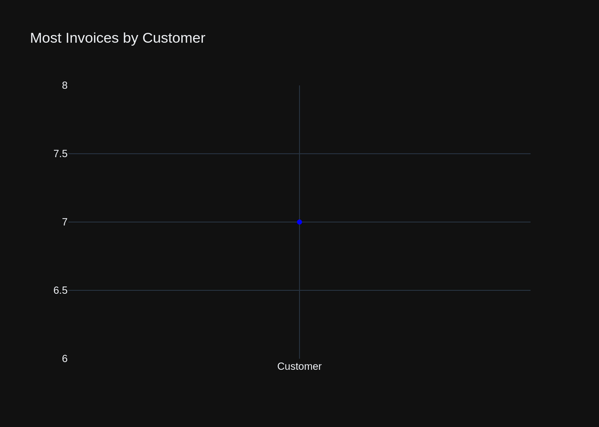

```
('SELECT C.LastName, COUNT(I.InvoiceId) AS TotalInvoices\nFROM Customer C\nJOIN Invoice I ON C.CustomerId = I.CustomerId\nGROUP BY C.CustomerId, C.LastName\nORDER BY TotalInvoices DESC\nLIMIT 1',
     LastName  TotalInvoices
 0  Gonçalves              7,
 Figure({
     'data': [{'marker': {'color': 'blue'}, 'mode': 'markers', 'type': 'scatter', 'x': ['Customer'], 'y': [7]}],
     'layout': {'template': '...', 'title': {'text': 'Most Invoices by Customer'}}
 }))
```

```python
question = """
     Find the customer with the most invoices
"""

vn.ask(question=question)
```

### Advanced SQL questions

```
Number of requested results 10 is greater than number of elements in index 1, updating n_results = 1
```

[output not shown]

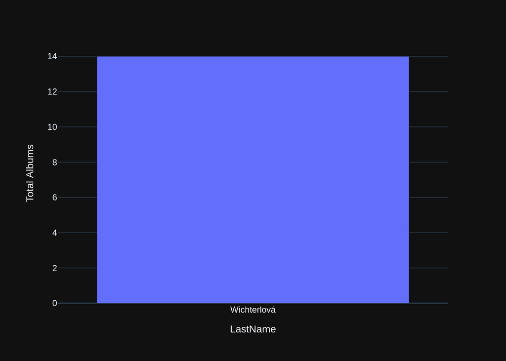

```
('SELECT C.LastName, SUM(IL.Quantity) AS TotalAlbums\nFROM Customer C\nJOIN InvoiceLine IL ON C.CustomerId = IL.InvoiceId\nGROUP BY C.LastName\nORDER BY TotalAlbums DESC\nLIMIT 1',
       LastName  TotalAlbums
 0  Wichterlová           14,
 Figure({
     'data': [{'alignmentgroup': 'True',
               'hovertemplate': 'LastName=%{x}<br>TotalAlbums=%{y}<extra></extra>',
               'legendgroup': '',
               'marker': {'color': '#636efa', 'pattern': {'shape': ''}},
               'name': '',
               'offsetgroup': '',
               'orientation': 'v',
               'showlegend': False,
               'textposition': 'auto',
               'type': 'bar',
               'x': array(['Wichterlová'], dtype=object),
               'xaxis': 'x',
               'y': array([14]),
               'yaxis': 'y'}],
     'layout': {'barmode': 'relative',
                'legend': {'tracegroupgap': 0},
                'margin': {'t': 60},
                'template': '...',
                'xaxis': {'anchor': 'y', 'domain': [0.0, 1.0], 'title': {'text': 'LastName'}},
                'yaxis': {'anchor': 'x', 'domain': [0.0, 1.0], 'title': {'text': 'Total Albums'}}}
 }))
```

```python
question = """
     Find the customer who bought the most albums in total quantity (across all invoices):
"""

vn.ask(question=question)
```

```
Number of requested results 10 is greater than number of elements in index 1, updating n_results = 1
```

[output not shown]

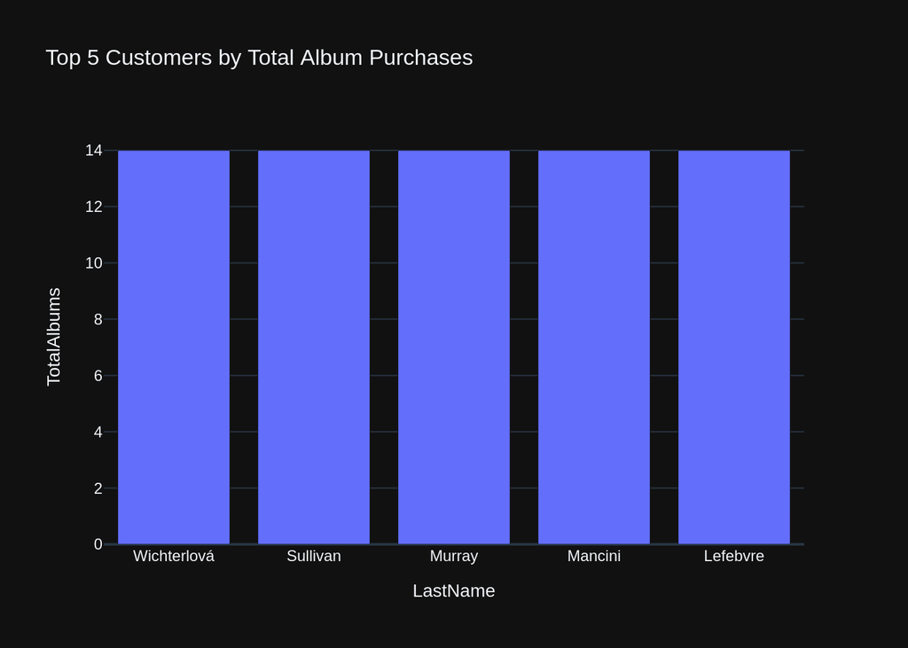

```
('SELECT C.LastName, SUM(IL.Quantity) AS TotalAlbums\nFROM Customer C\nJOIN InvoiceLine IL ON C.CustomerId = IL.InvoiceId\nGROUP BY C.LastName\nORDER BY TotalAlbums DESC\nLIMIT 5',
       LastName  TotalAlbums
 0  Wichterlová           14
 1     Sullivan           14
 2       Murray           14
 3      Mancini           14
 4     Lefebvre           14,
 Figure({
     'data': [{'alignmentgroup': 'True',
               'hovertemplate': 'LastName=%{x}<br>TotalAlbums=%{y}<extra></extra>',
               'legendgroup': '',
               'marker': {'color': '#636efa', 'pattern': {'shape': ''}},
               'name': '',
               'offsetgroup': '',
               'orientation': 'v',
               'showlegend': False,
               'textposition': 'auto',
               'type': 'bar',
               'x': array(['Wichterlová', 'Sullivan', 'Murray', 'Mancini', 'Lefebvre'],
                          dtype=object),
               'xaxis': 'x',
               'y': array([14, 14, 14, 14, 14]),
               'yaxis': 'y'}],
     'layout': {'barmode': 'relative',
                'legend': {'tracegroupgap': 0},
                'template': '...',
                'title': {'text': 'Top 5 Customers by Total Album Purchases'},
                'xaxis': {'anchor': 'y', 'domain': [0.0, 1.0], 'title': {'text': 'LastName'}},
                'yaxis': {'anchor': 'x', 'domain': [0.0, 1.0], 'title': {'text': 'TotalAlbums'}}}
 }))
```

```python
question = """
     Find the top 5 customer who bought the most albums in total quantity (across all invoices):
"""

vn.ask(question=question)
```

```
Number of requested results 10 is greater than number of elements in index 1, updating n_results = 1
```

[output not shown]

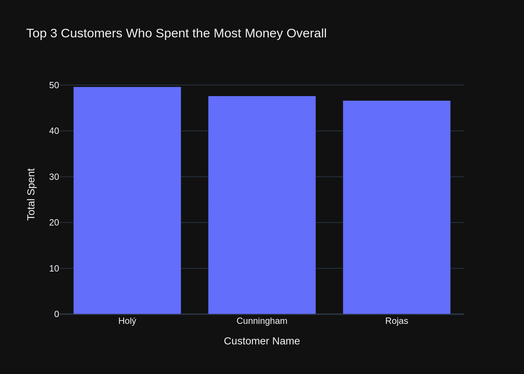

```
('SELECT C.LastName, SUM(I.Total) AS TotalSpent\nFROM Customer C\nJOIN Invoice I ON C.CustomerId = I.CustomerId\nGROUP BY C.LastName\nORDER BY TotalSpent DESC\nLIMIT 3\n',
      LastName  TotalSpent
 0        Holý       49.62
 1  Cunningham       47.62
 2       Rojas       46.62,
 Figure({
     'data': [{'alignmentgroup': 'True',
               'hovertemplate': 'LastName=%{x}<br>TotalSpent=%{y}<extra></extra>',
               'legendgroup': '',
               'marker': {'color': '#636efa', 'pattern': {'shape': ''}},
               'name': '',
               'offsetgroup': '',
               'orientation': 'v',
               'showlegend': False,
               'textposition': 'auto',
               'type': 'bar',
               'x': array(['Holý', 'Cunningham', 'Rojas'], dtype=object),
               'xaxis': 'x',
               'y': array([49.62, 47.62, 46.62]),
               'yaxis': 'y'}],
     'layout': {'barmode': 'relative',
                'legend': {'tracegroupgap': 0},
                'template': '...',
                'title': {'text': 'Top 3 Customers Who Spent the Most Money Overall'},
                'xaxis': {'anchor': 'y', 'domain': [0.0, 1.0], 'title': {'text': 'Customer Name'}},
                'yaxis': {'anchor': 'x', 'domain': [0.0, 1.0], 'title': {'text': 'Total Spent'}}}
 }))
```

```python
question = """
     Find the top 3 customers who spent the most money overall:
"""

vn.ask(question=question)
```

```
Number of requested results 10 is greater than number of elements in index 1, updating n_results = 1
```

[output not shown]

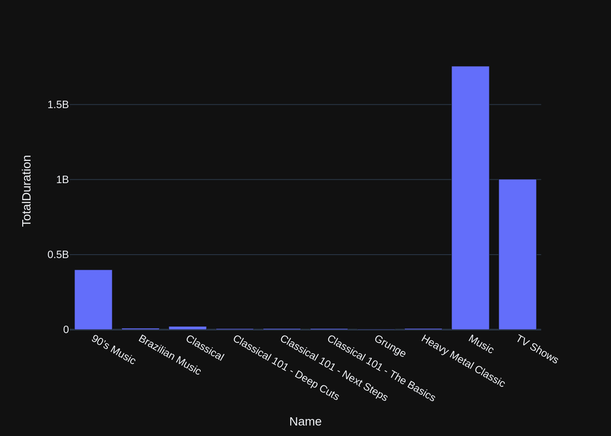

```
('SELECT P.Name, SUM(T.Milliseconds) AS TotalDuration\nFROM PlaylistTrack PT\nJOIN Track T ON PT.TrackId = T.TrackId\nJOIN Playlist P ON PT.PlaylistId = P.PlaylistId\nGROUP BY P.Name\nHAVING COUNT(*) >= 10',
                          Name  TotalDuration
 0                  90’s Music      398705153
 1             Brazilian Music        9486559
 2                   Classical       21770592
 3   Classical 101 - Deep Cuts        6755730
 4  Classical 101 - Next Steps        7575051
 5  Classical 101 - The Basics        7439811
 6                      Grunge        4122018
 7         Heavy Metal Classic        8206312
 8                       Music     1755366166
 9                    TV Shows     1002189914,
 Figure({
     'data': [{'alignmentgroup': 'True',
               'hovertemplate': 'Name=%{x}<br>TotalDuration=%{y}<extra></extra>',
               'legendgroup': '',
               'marker': {'color': '#636efa', 'pattern': {'shape': ''}},
               'name': '',
               'offsetgroup': '',
               'orientation': 'v',
               'showlegend': False,
               'textposition': 'auto',
               'type': 'bar',
               'x': array(['90’s Music', 'Brazilian Music', 'Classical',
                           'Classical 101 - Deep Cuts', 'Classical 101 - Next Steps',
                           'Classical 101 - The Basics', 'Grunge', 'Heavy Metal Classic', 'Music',
                           'TV Shows'], dtype=object),
               'xaxis': 'x',
               'y': array([ 398705153,    9486559,   21770592,    6755730,    7575051,    7439811,
                              4122018,    8206312, 1755366166, 1002189914]),
               'yaxis': 'y'}],
     'layout': {'barmode': 'relative',
                'legend': {'tracegroupgap': 0},
                'margin': {'t': 60},
                'template': '...',
                'xaxis': {'anchor': 'y', 'domain': [0.0, 1.0], 'title': {'text': 'Name'}},
                'yaxis': {'anchor': 'x', 'domain': [0.0, 1.0], 'title': {'text': 'TotalDuration'}}}
 }))
```

```python
question = """
     Get all playlists containing at least 10 tracks and the total duration of those tracks:
"""

vn.ask(question=question)
```

```python
question = """
     Identify artists who have albums with tracks appearing in multiple genres:
"""

vn.ask(question=question)
```

```
Number of requested results 10 is greater than number of elements in index 1, updating n_results = 1
```

[output not shown]

## Launch the User Interface

[figure not shown]

## Next Steps

Using Vanna via Jupyter notebooks is great for getting started but check out additional customizable interfaces like the

- [Streamlit app](https://github.com/vanna-ai/vanna-streamlit)
- [Flask app](https://github.com/vanna-ai/vanna-flask)
- [Slackbot](https://github.com/vanna-ai/vanna-slack)